# Practical Machine Learning Project

## Background

Using devices such as Jawbone Up, Nike FuelBand, and Fitbit it is now possible to collect a large amount of data about personal activity relatively inexpensively. These type of devices are part of the quantified self movement - a group of enthusiasts who take measurements about themselves regularly to improve their health, to find patterns in their behavior, or because they are tech geeks. One thing that people regularly do is quantify how much of a particular activity they do, but they rarely quantify how well they do it. In this project, your goal will be to use data from accelerometers on the belt, forearm, arm, and dumbell of 6 participants. They were asked to perform barbell lifts correctly and incorrectly in 5 different ways. More information is available from the website here " http://groupware.les.inf.puc-rio.br/har" (see the section on the Weight Lifting Exercise Dataset).

## Data Source

The training data for this project are available here:

https://d396qusza40orc.cloudfront.net/predmachlearn/pml-training.csv

The test data are available here:

https://d396qusza40orc.cloudfront.net/predmachlearn/pml-testing.csv

The data for this project come from this source: http://groupware.les.inf.puc-rio.br/har. If you use the document you create for this class for any purpose please cite them as they have been very generous in allowing their data to be used for this kind of assignment.

## Download and Load Data

```r
library(caret)
```

```r
traindata <- "http://d396qusza40orc.cloudfront.net/predmachlearn/pml-training.csv"
testdata<- "http://d396qusza40orc.cloudfront.net/predmachlearn/pml-testing.csv"

training <- read.csv(url(traindata), na.strings=c("NA","#DIV/0!",""))
testing <- read.csv(url(testdata), na.strings=c("NA","#DIV/0!",""))
```

## Data Cleaning

Clean data before partioning. Removing NA from the dataset to increase the accuracy

```r
cols.without.na <- names(testing[,colSums(is.na(testing)) == 0])[8:59]
training <-training[, c(cols.without.na,"classe")]
testing <- testing[,c(cols.without.na,"problem_id")]
dim(training); dim(testing)
```

```
## [1] 19622    53
```

```
## [1] 20 53
```

## Partion training dataset

```r
inTrain <- createDataPartition(y=training$classe, p=0.6, list=FALSE)
mytraining <- training[inTrain, ]; mytesting <- training[-inTrain, ]
dim(mytraining); dim(mytesting)
```

```
## [1] 11776    53
```

```
## [1] 7846   53
```

clean the NearZeroVariance Variables

```r
nzv <- nearZeroVar(mytraining, saveMetrics=TRUE)
mytraining <- mytraining[,nzv$nzv==FALSE]

nzv<- nearZeroVar(mytesting,saveMetrics=TRUE)
mytesting <- mytesting[,nzv$nzv==FALSE]
```

## Prediction

### Decision Tree

First we test with the basic decision tree

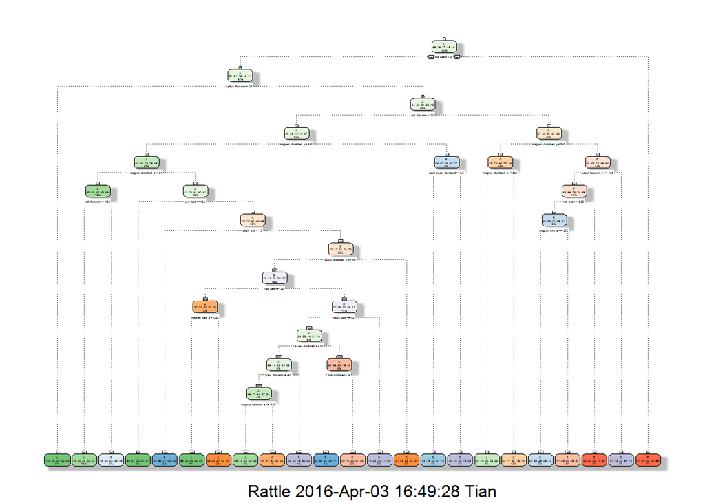

```r
library(rpart)
library(rpart.plot)
library(rattle)
Test1_DT<-rpart(classe~., data=mytraining, method="class")
fancyRpartPlot(Test1_DT)
```

Then run prediction model and use confusion matrix to test results.

```r
library(RColorBrewer)
Prediction1<-predict(Test1_DT, mytesting, type ="class")
confusionMatrix(Prediction1, mytesting$classe)
```

```
## Confusion Matrix and Statistics
##
##           Reference
## Prediction    A    B    C    D    E
##          A 2016  278   55  108   55
##          B   69  847  138  130  139
##          C   46  171 1076  173  143
##          D   71  113   99  809   91
##          E   30  109    0   66 1014
##
## Overall Statistics
##
##                Accuracy : 0.7344
##                  95% CI : (0.7245, 0.7441)
##     No Information Rate : 0.2845
##     P-Value [Acc > NIR] : < 2.2e-16
##
##                   Kappa : 0.6626
##  Mcnemar's Test P-Value : < 2.2e-16
##
## Statistics by Class:
##
##                      Class: A Class: B Class: C Class: D Class: E
## Sensitivity            0.9032   0.5580   0.7865   0.6291   0.7032
## Specificity            0.9116   0.9248   0.9177   0.9430   0.9680
## Pos Pred Value         0.8025   0.6402   0.6687   0.6839   0.8318
## Neg Pred Value         0.9595   0.8971   0.9532   0.9284   0.9354
## Prevalence             0.2845   0.1935   0.1744   0.1639   0.1838
## Detection Rate         0.2569   0.1080   0.1371   0.1031   0.1292
## Detection Prevalence   0.3202   0.1686   0.2051   0.1508   0.1554
## Balanced Accuracy      0.9074   0.7414   0.8521   0.7860   0.8356
```

### Randome Forest

Now test the Randome Forest method and see if it is better than decision tree.

```r
library(randomForest)
Test2<-randomForest(classe~. , data=mytraining)
Test2_RF<-predict(Test2, mytesting, type="class")
confusionMatrix(Test2_RF, mytesting$classe)
```

```
## Confusion Matrix and Statistics
##
##           Reference
## Prediction    A    B    C    D    E
##          A 2231    7    0    0    0
##          B    0 1504    8    0    0
##          C    0    7 1359   10    0
##          D    0    0    1 1276    3
##          E    1    0    0    0 1439
##
## Overall Statistics
##
##                Accuracy : 0.9953
##                  95% CI : (0.9935, 0.9967)
##     No Information Rate : 0.2845
##     P-Value [Acc > NIR] : < 2.2e-16
##
##                   Kappa : 0.994
##  Mcnemar's Test P-Value : NA
##
## Statistics by Class:
##
##                      Class: A Class: B Class: C Class: D Class: E
## Sensitivity            0.9996   0.9908   0.9934   0.9922   0.9979
## Specificity            0.9988   0.9987   0.9974   0.9994   0.9998
## Pos Pred Value         0.9969   0.9947   0.9876   0.9969   0.9993
## Neg Pred Value         0.9998   0.9978   0.9986   0.9985   0.9995
## Prevalence             0.2845   0.1935   0.1744   0.1639   0.1838
## Detection Rate         0.2843   0.1917   0.1732   0.1626   0.1834
## Detection Prevalence   0.2852   0.1927   0.1754   0.1631   0.1835
## Balanced Accuracy      0.9992   0.9948   0.9954   0.9958   0.9989
```

From the output, we can see the accuracy is around 0.99, which is much higher than the decision tree. Random Forest provides better results.

# Assignment File

Use Random Forest to get the test set.

```r
Test2_RF_2<- predict(Test2, testing, type="class")
Test2_RF_2
```

```
##  1  2  3  4  5  6  7  8  9 10 11 12 13 14 15 16 17 18 19 20
##  B  A  B  A  A  E  D  B  A  A  B  C  B  A  E  E  A  B  B  B
## Levels: A B C D E
```